This is shiny-rized project of the original multi-cancer early detection.

The goal of this project is to develop user-friendly web application for simulate the detection power of multi-cancer early detection test under different scenarios, including: different dwell time setting, different cancer prevalence, different cancer detection sensitivity, and interval of the test.

# Quick start

You can access the web application through the following link: https://chunhuigu.shinyapps.io/simulate_slip_rate/

The online application can be slow so please be patient.

Or download from github and run the following command in R console when you are at root directory of the project

```
shinyAppDir('.', options = list())
```

# Step 1: Define different dwell scenarios

The first step is to define different dwell group. In the table there are four different groups: A, B, C, D, each group also have four different cancer progress scenarios: 1) very slow, 2) slow, 3) fast, 4) aggresively fast then for each group and progress scenario, the 1-4 cancer stage will a have a fixed dwell time

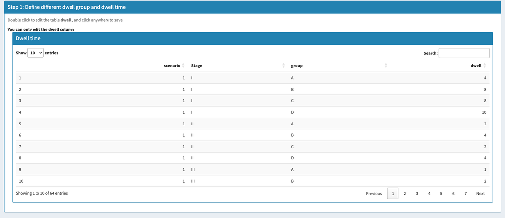

# Step 2: Select cancer group

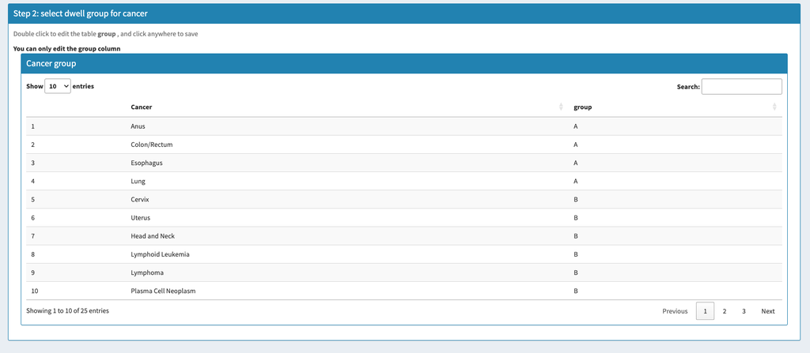

# Step 2B: Final check the cancer dwell scenarios

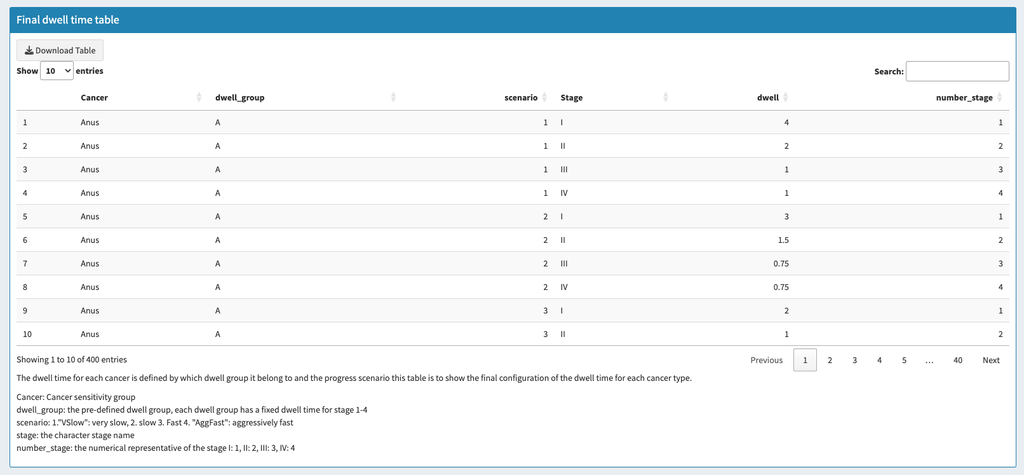

Step 2B: Final check the cancer dwell scenarios

# Step 3: Define the cancer detection sensitivity

We load the cancer detection sensitivity from the original multi-cancer early detection test, but user can simply modify the file to change the cancer detection sensitivity. Later a input feature will be added to allow on-fly change of the cancer detection sensitivity

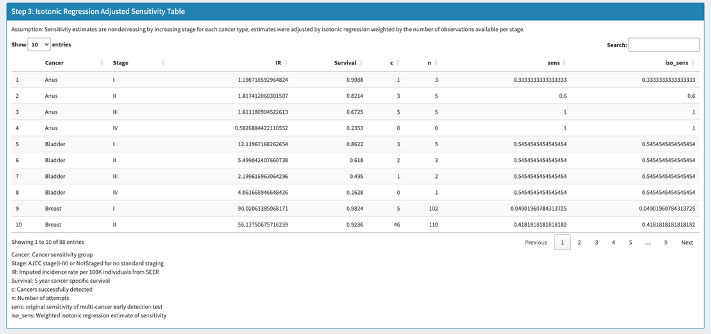

# Step 4: Setting detection slip rate

The user can set the detection slip rate, which is the probability that the cancer is not detected by the test for a stage and the cancer get into the next stage. The slip rate is defined by three parameter: the slip rate density model, the expected dwell time for the cancer to stay in the stage, and the interval between screenings. Here we use Weibull distribution (more distribution will be added later) to model the slip rate density. User can slide to adjust weibull shape parameter and screen interval. The Cumulative slip probability plot will show the cumulative slip probability for a stage of the cancer with dwell=4 for example.

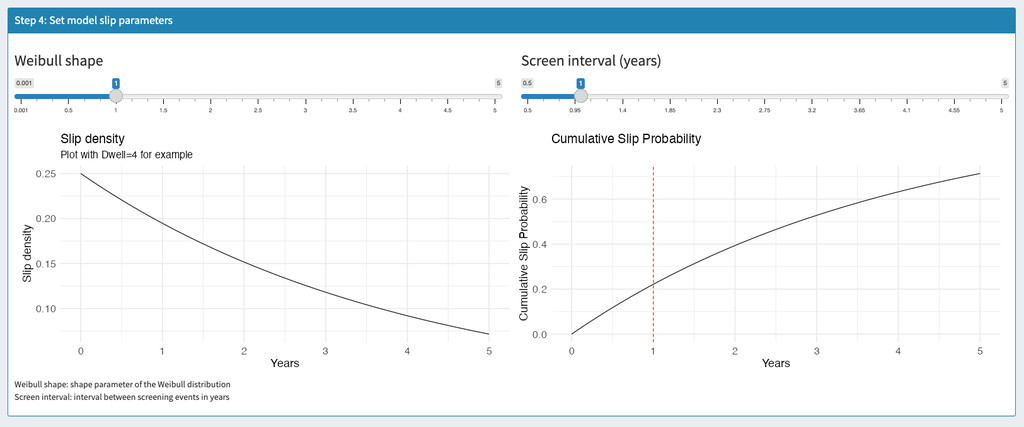

# step 5: check simulation performance

This page show all important information for the simulation. The look-up table for the variable can be found in the bottom of each page.

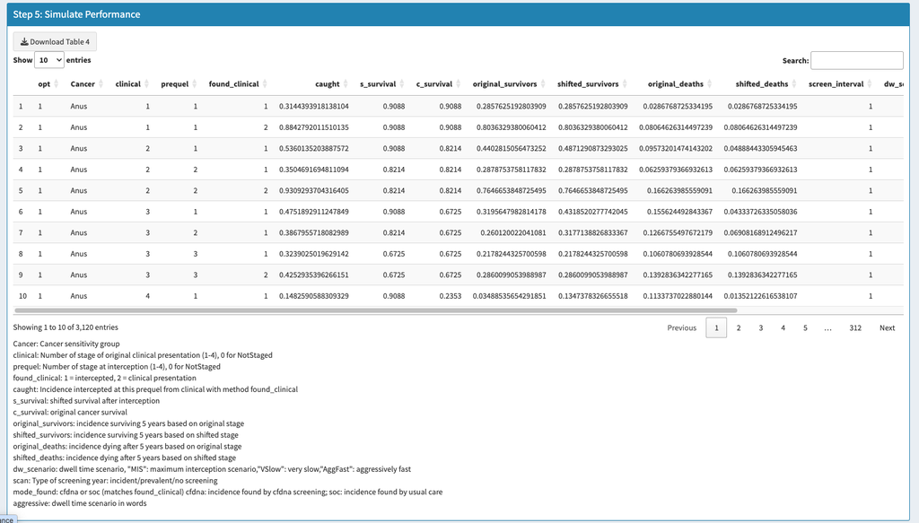

# Step 6: Reconstruct Flow Diagrams

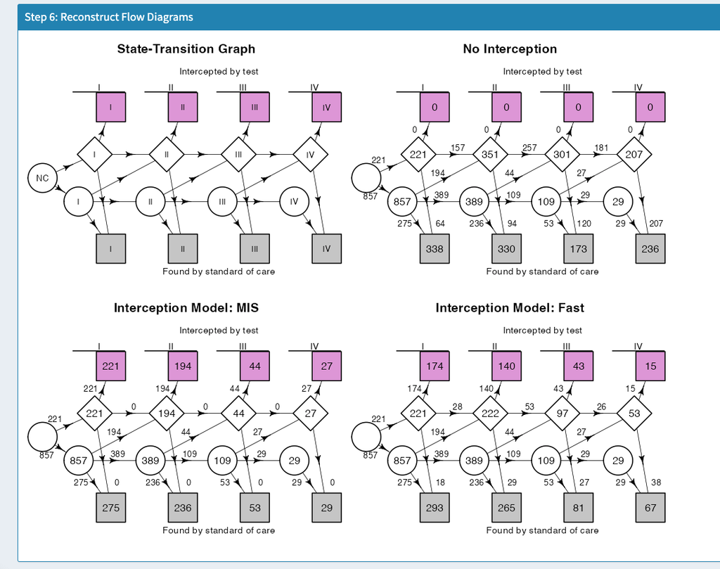

# Step 7: Check sanky plot

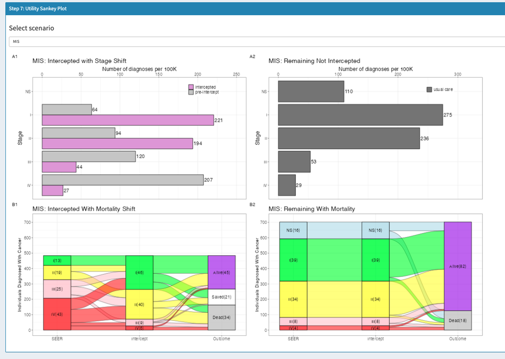

Step 7: Check the detection power

# Step 8: Check the stage-shifting power

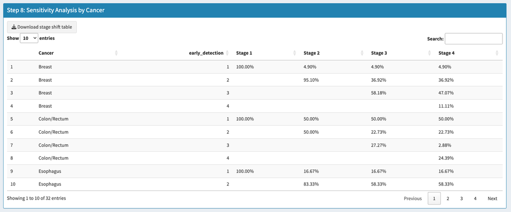